# Gov1005 Problem Set 3

Rebecca Xi

2/19/2020

## Mad Libs

1. 51 respondents are in the treatment group.
2. Among respondents from the treatment group, the government has an average 6.8367347 rating.
3. The most common rating for the government’s handling of traffic is 5.
4. 9 respondents have given the government a 10 rating overall or on demolitions or on traffic.
5. But only 1 gave the government a 10 rating overall and on demolitions and on traffic.

The variable ‘news_source’ asks respondents to list which news sources they get their news from. Some respondents answered more than one option, so their answer lists a number of letters together. A means “Television”, B means “Newspapers”, C means “Radio”, etc.

6. The number of respondents who get their news from Television is 36.
7. Of the 4 different locations where the respondents were surveyed, the following two locations end with “square”: chang’an square, yinghua square.

## Data Wrangling

### 1.

Untidy Data

| Respondent Number | Evaluations of Government Performance Overall | Evaluations of Government Performance Traffic | Evaluations of Government Performance Demolitions |
| --- | --- | --- | --- |
| 1 | 7 | 5 | 4 |
| 2 | 5 | 8 | 8 |
| 3 | 3 | 1 | 2 |
| 4 | NA | NA | NA |
| 5 | 9 | 8 | 8 |
| 6 | 6 | 6 | 6 |
| 7 | 8 | 8 | 8 |
| 8 | 5 | 5 | 1 |
| 9 | 2 | 6 | 2 |
| 10 | 5 | 9 | 4 |

Tidy Data

| Respondent Number | Type of Evaluation | Performance Rating |
| --- | --- | --- |
| 1 | Overall | 7 |
| 1 | Traffic | 5 |
| 1 | Demo | 4 |
| 2 | Overall | 5 |
| 2 | Traffic | 8 |
| 2 | Demo | 8 |
| 3 | Overall | 3 |
| 3 | Traffic | 1 |
| 3 | Demo | 2 |
| 4 | Overall | NA |
| 4 | Traffic | NA |
| 4 | Demo | NA |
| 5 | Overall | 9 |
| 5 | Traffic | 8 |
| 5 | Demo | 8 |
| 6 | Overall | 6 |
| 6 | Traffic | 6 |
| 6 | Demo | 6 |
| 7 | Overall | 8 |
| 7 | Traffic | 8 |
| 7 | Demo | 8 |
| 8 | Overall | 5 |
| 8 | Traffic | 5 |
| 8 | Demo | 1 |
| 9 | Overall | 2 |
| 9 | Traffic | 6 |
| 9 | Demo | 2 |
| 10 | Overall | 5 |
| 10 | Traffic | 9 |
| 10 | Demo | 4 |

### 2.

Potential Outcomes<sup>1</sup>

| Respondent | Treatment | Control | Potential Outcomes Under Control | Potential Outcomes Under Treatment |
| --- | --- | --- | --- | --- |
| 1 | 1 | 0 | ? | 7 |
| 2 | 1 | 0 | ? | 5 |
| 3 | 0 | 1 | 3 | ? |
| 4 | 1 | 0 | ? | NA |
| 5 | 0 | 1 | 9 | ? |
| 6 | 0 | 1 | 6 | ? |
| 7 | 0 | 1 | 8 | ? |
| 8 | 0 | 1 | 5 | ? |
| 9 | 0 | 1 | 2 | ? |
| 10 | 1 | 0 | ? | 5 |

<sup>*1*</sup> Treatment is a 2 minute video about Chinese sports performance

### 3.

Highest Evaluators of Government Performance on Traffic:<sup>1</sup>

Among Treated Individuals

| Respondent | Evaluate Government Performance | Age | Gender |
| --- | --- | --- | --- |
| 22 | 10 | 28 | Male |
| 82 | 10 | 24 | Female |
| 99 | 10 | 21 | Female |
| 10 | 9 | 35 | Male |
| 13 | 9 | 17 | Male |

<sup>*1*</sup> Evaluation on Scale from 1 to 10

### 4.

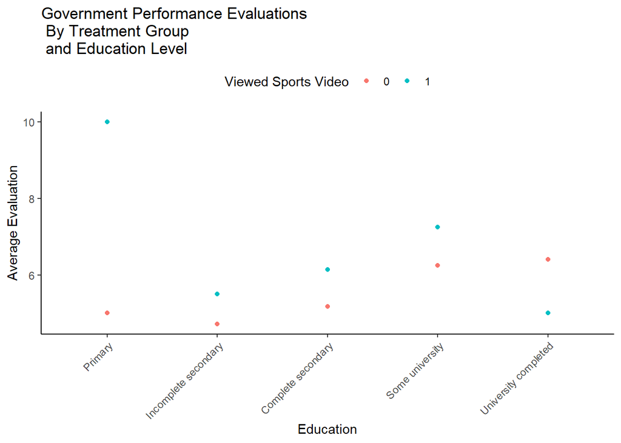

### 5.

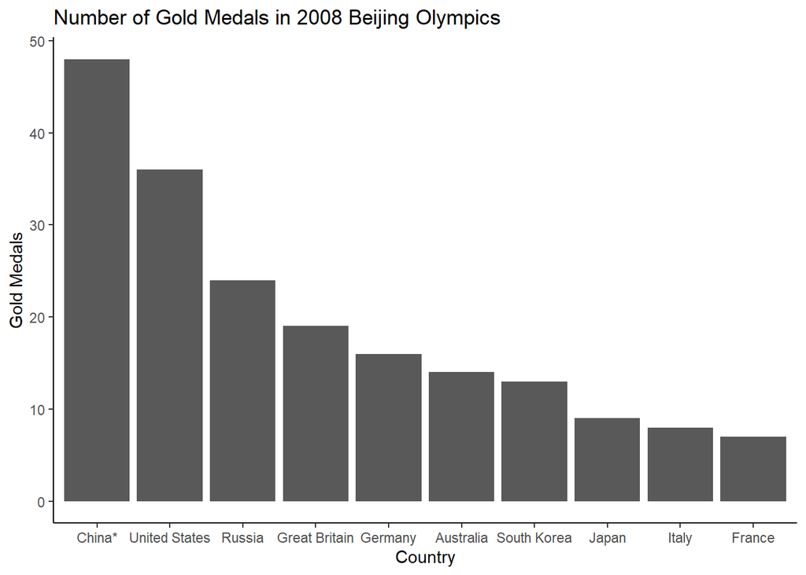

## Colleagues

- Lara Teich
- Ishan Bhaat
- Grace Pan
- Stephanie Cheng
- Rachel Phan
- Sophie Webster
- Lainey Newman
- Jacob Hansen
- Jack Kelly